# experiment

김호현

2016년 5월 28일

Open experiment dataset which contains sales from 2010-1-1 to 2016-5-18.  
I decomposed original salse data and inserted some noise deliberately.

```r
setwd("~/Documents/KNOU/Computer_network/TermProject")
load("experiment.RData")
```

## 1. Data preparation

Let see what dataset looks like.  
Dataset is composed of seasonal, trend, noise, label.  
Noise is the part that I inserted deliberately for the purpose of experiment.  
Label indicate if the data is anomalous. If noise is bigger than $2\sigma$, it is TRUE.

### Original data

```r
head(select(sales, date, wday, sales))
```

```
## Source: local data frame [6 x 3]
##
##         date wday  sales
## 1 2010-01-01  Fri  17.05
## 2 2010-01-02  Sat  22.09
## 3 2010-01-03  Sun  18.67
## 4 2010-01-04  Mon 153.76
## 5 2010-01-05  Tue 165.05
## 6 2010-01-06  Wed 175.62
```

### Decompose

```r
select(sales, date, wday, seasonal, trend, remainder)
```

```
## Source: local data frame [2,330 x 5]
##
##          date wday seasonal  trend remainder
## 1  2010-01-01  Fri   132.08 163.78   -278.81
## 2  2010-01-02  Sat  -155.52 164.09     13.52
## 3  2010-01-03  Sun  -176.59 164.40     30.86
## 4  2010-01-04  Mon    52.98 164.71    -63.93
## 5  2010-01-05  Tue    43.91 165.02    -43.88
## 6  2010-01-06  Wed    45.35 165.33    -35.07
## 7  2010-01-07  Thu    57.79 165.65    -48.35
## 8  2010-01-08  Fri   132.08 165.96    -48.26
## 9  2010-01-09  Sat  -155.52 166.27     26.44
## 10 2010-01-10  Sun  -176.59 166.58     30.40
## ..        ...  ...      ...    ...       ...
```

### Insert noise

```r
select(sales, date, wday, sd, noise)
```

```
## Source: local data frame [2,330 x 4]
##
##          date wday    sd   noise
## 1  2010-01-01  Fri 71.93   15.80
## 2  2010-01-02  Sat 12.78    5.14
## 3  2010-01-03  Sun 16.74  -23.28
## 4  2010-01-04  Mon 48.07   27.05
## 5  2010-01-05  Tue 48.25 -104.70
## 6  2010-01-06  Wed 49.21    1.96
## 7  2010-01-07  Thu 53.59  -14.03
## 8  2010-01-08  Fri 71.93 -132.00
## 9  2010-01-09  Sat 12.78    2.50
## 10 2010-01-10  Sun 16.74   13.56
## ..        ...  ...   ...     ...
```

### Experimental data

```r
select(sales, date, wday, new.sales, label)
```

```
## Source: local data frame [2,330 x 4]
##
##          date wday new.sales label
## 1  2010-01-01  Fri    311.66 FALSE
## 2  2010-01-02  Sat     13.71 FALSE
## 3  2010-01-03  Sun    -35.47 FALSE
## 4  2010-01-04  Mon    244.74 FALSE
## 5  2010-01-05  Tue    104.23  TRUE
## 6  2010-01-06  Wed    212.64 FALSE
## 7  2010-01-07  Thu    209.41 FALSE
## 8  2010-01-08  Fri    166.04 FALSE
## 9  2010-01-09  Sat     13.25 FALSE
## 10 2010-01-10  Sun      3.55 FALSE
## ..        ...  ...       ...   ...
```

Let’s check if there is difference in variance of remainder(noise) by weekday.

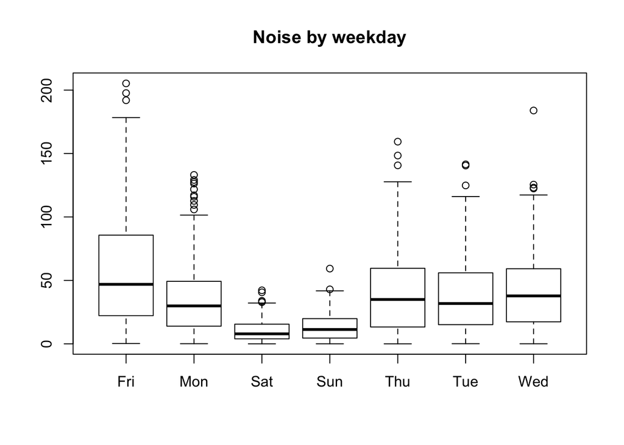

```r
boxplot(abs(noise) ~ wday, sales, main = "Noise by weekday")
```

Cleary the mean and sd is different by weekday. Sat, Sun is lower than others and Fri day is bigger than others.

```r
sales %>% group_by(wday) %>% summarise(mean(abs(noise)), sd(abs(noise)))
```

```
## Source: local data frame [7 x 3]
##
##   wday mean(abs(noise)) sd(abs(noise))
## 1  Fri         58.86249       44.10019
## 2  Mon         35.81171       28.32467
## 3  Sat         10.36628        8.32923
## 4  Sun         13.53339       10.56134
## 5  Thu         41.69663       32.84780
## 6  Tue         37.76219       28.73132
## 7  Wed         41.42333       29.15067
```

## 2. Alogoritm comparation I : Uni-threshold vs Multi-threshold

Let’s compare detection result between one threshold and multi threshold.

### Decompose with stl

```r
freq = 7
t_wnd = 60
```

```r
temp <- as.vector(as.matrix(select(sales, new.sales)))
sales_ts <- ts(temp, frequency = freq)
fit <- stl(sales_ts, s.window = "periodic", t.window = t_wnd, robust = T)
sales_decomp <- fit$time.series

df1 <- data.frame(date = sales[,"date"], wday = sales[,"wday"],
                  sales = sales[,"new.sales"], label = sales[,"label"],
                  seasonal = as.numeric(sales_decomp[,"seasonal"]),
                  trend = as.numeric(sales_decomp[,"trend"]),
                  remainder = as.numeric(sales_decomp[,"remainder"]))
df1 <- tbl_df(df1)
```

### Check if there is differnce of variance between weekdays

```r
# anova test ----------------------------------------------------
fit <- aov(abs(remainder) ~ wday, df1)
summary(fit)
```

```
##               Df  Sum Sq Mean Sq F value Pr(>F)
## wday           6  530805   88468   108.6 <2e-16 ***
## Residuals   2323 1891858     814
## ---
## Signif. codes:  0 '***' 0.001 '**' 0.01 '*' 0.05 '.' 0.1 ' ' 1
```

P value is less than 0.001 which clearly means that variance is different between weekdays.

### Calculate threshold using sd by weekday.

```r
sd_uni  <- df1 %>% summarise(sd_uni = sd(remainder))
sd_yoil <- df1 %>% group_by(wday) %>% summarise(sd_yoil = sd(remainder))
df1 <- mutate(df1, sd_uni = rep(as.numeric(sd_uni), dim(df1)[1]))
df1 <- left_join(df1, sd_yoil)
df1 <- mutate(df1, theta1 = sd_uni * 1.96, theta2 = sd_yoil * 1.96)
```

### Detection comparison between *One-threshold* and *Multi-threhold*

```r
df1 <- mutate(df1, detect1 = abs(remainder) > theta1, detect2 = abs(remainder) > theta2)
```

- detect1 : result by one threshold (sd_uni * 1.96)
- detect2 : result by multi threshold (sd_yoil * 1.96)

#### Precision, Recall, F-score

Let’s claculate precision, recall, F-rate

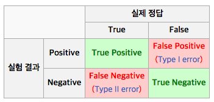

- Precision = $\frac{t_p}{t_p + f_p}$
- Recall = $\frac{t_p}{t_p + f_n}$
- F-score = $\frac{2 * Precision * recall}{precision + recall}$

#### Detect1 - One-threshold

```r
result <- count(df1, label, detect1)
result
```

```
## Source: local data frame [4 x 3]
## Groups: label
##
##   label detect1    n
## 1 FALSE   FALSE 2125
## 2 FALSE    TRUE   78
## 3  TRUE   FALSE   51
## 4  TRUE    TRUE   76
```

- Precision = 49.4%
- Recall = 59.8%
- F-score = 54.1%

#### Detect2 - Multi-threshold

```r
result <- count(df1, label, detect2)
result
```

```
## Source: local data frame [4 x 3]
## Groups: label
##
##   label detect2    n
## 1 FALSE   FALSE 2173
## 2 FALSE    TRUE   30
## 3  TRUE   FALSE   28
## 4  TRUE    TRUE   99
```

- Precision = 76.7%
- Recall = 78.0%
- F-score = 77.3%

## Algorithm comparison - trend decompose : Moving average vs MA + B-spline vs Loess

```r
##### Trend extracting coparision -------------------------------------------
## input: frequency, t_wnd(stl t.window), k(bspline internal knots)
freq = 7
t_wnd = 31
# k: internal knots -- last day of every month
sales_xts <- xts(sales[,-1], order.by = sales$date)
k <- index(sales_xts[endpoints(sales_xts, on = "months")])
k <- k[-length(k)] # delete last month

## moving average
dcom_ma <- decompose(sales_ts, type = "additive")
ma <- as.numeric(dcom_ma$trend)
df2 <- data.frame(date = sales[,"date"], wday = sales[,"wday"],
                  sales = sales[,"new.sales"], label = sales[,"label"],
                  seasonal = as.numeric(dcom_ma$seasonal),
                  trend.ma = as.numeric(dcom_ma$trend))
df2 <- tbl_df(df2)

## b-spline regression
model = lm(trend.ma ~ bs(date, knots = k, degree = 3), data = df2)
bs.reg = predict(model, newdata = data.frame(date=sales$date))
df2 <- mutate(df2, trend.bs = as.numeric(bs.reg))

# stl
temp <- as.vector(as.matrix(select(sales, new.sales)))
sales_ts <- ts(temp, frequency = freq)
fit <- stl(sales_ts, s.window = "periodic", t.window = t_wnd, robust = T)
dcom_stl <- fit$time.series
df2 <- mutate(df2, trend.stl = as.numeric(dcom_stl[,"trend"]))
## plot

df2 <- mutate(df2,
              random.ma = new.sales - seasonal - trend.ma,
              random.bs = new.sales - seasonal - trend.bs,
              random.stl = new.sales - seasonal - trend.stl)

# theta: ma
theta.ma <- df2 %>% group_by(wday) %>% summarise(theta.ma = sd(random.ma, na.rm = TRUE) * 1.96)
df2 <- left_join(df2, theta.ma)
# theta: bs
theta.bs <- df2 %>% group_by(wday) %>% summarise(theta.bs = sd(random.bs, na.rm = TRUE) * 1.96)
df2 <- left_join(df2, theta.bs)
# detect - stl
theta.stl <- df2 %>% group_by(wday) %>% summarise(theta.stl = sd(random.stl, na.rm = TRUE) * 1.96)
df2 <- left_join(df2, theta.stl)
# detect
df2 <- mutate(df2,
              detect.ma = abs(random.ma) > theta.ma,
              detect.bs = abs(random.bs) > theta.bs,
              detect.stl = abs(random.stl) > theta.stl)
df2 <- filter(df2, date > as.Date("2010-01-31") & date < as.Date("2016-05-01"))
```

### comparison trend decompose result

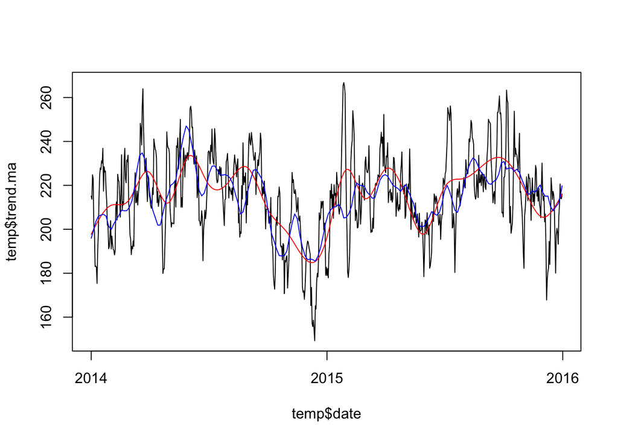

```r
temp <- filter(df2, date >= as.Date("2014-01-01") & date <= as.Date("2015-12-31"))
plot(temp$trend.ma ~ temp$date, type = "l")
lines(temp$trend.bs ~ temp$date, col = "red")
lines(temp$trend.stl ~ temp$date, col = "blue")
```

### Detect result: precision, recall, F-score

```r
# count
rs.ma <- count(df2, label, detect.ma)
rs.ma <- filter(rs.ma, !is.na(detect.ma))
rs.bs <- count(df2, label, detect.bs)
rs.stl <- count(df2, label, detect.stl)
```

#### Moving average

```r
rs.ma
```

```
## Source: local data frame [4 x 3]
## Groups: label
##
##   label detect.ma    n
## 1 FALSE     FALSE 2102
## 2 FALSE      TRUE   54
## 3  TRUE     FALSE   57
## 4  TRUE      TRUE   68
```

- Precision = 55.7%
- Recall = 54.4%
- F-score = 55.1%

#### MA + B-spline regression

```r
rs.bs
```

```
## Source: local data frame [4 x 3]
## Groups: label
##
##   label detect.bs    n
## 1 FALSE     FALSE 2129
## 2 FALSE      TRUE   27
## 3  TRUE     FALSE   37
## 4  TRUE      TRUE   88
```

- Precision = 76.5%
- Recall = 70.4%
- F-score = 73.3%

#### STL (Loess)

```r
rs.stl
```

```
## Source: local data frame [4 x 3]
## Groups: label
##
##   label detect.stl    n
## 1 FALSE      FALSE 2113
## 2 FALSE       TRUE   43
## 3  TRUE      FALSE   32
## 4  TRUE       TRUE   93
```

- Precision = 68.4%
- Recall = 74.4%
- F-score = 71.3%

### Detection result: plot

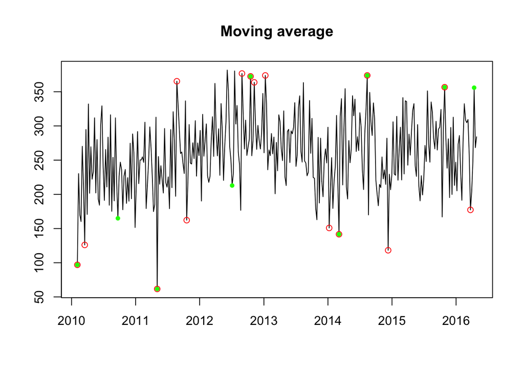

```r
# ploting result
temp <- filter(df2, wday == "Wed")
anom_o <- filter(temp, label == TRUE)
anom_ma <- filter(df2, wday == "Wed" & detect.ma == TRUE)
anom_bs <- filter(df2, wday == "Wed" & detect.bs == TRUE)
anom_stl <- filter(df2, wday == "Wed" & detect.stl == TRUE)
## anoms detected by moving average
plot(temp$date, temp$new.sales, type = "l", xlab = "", ylab = "", main = "Moving average")
points(anom_o$date, anom_o$new.sales, col = "red")
points(anom_ma$date, anom_ma$new.sales, col = "green", pch = 20)
```

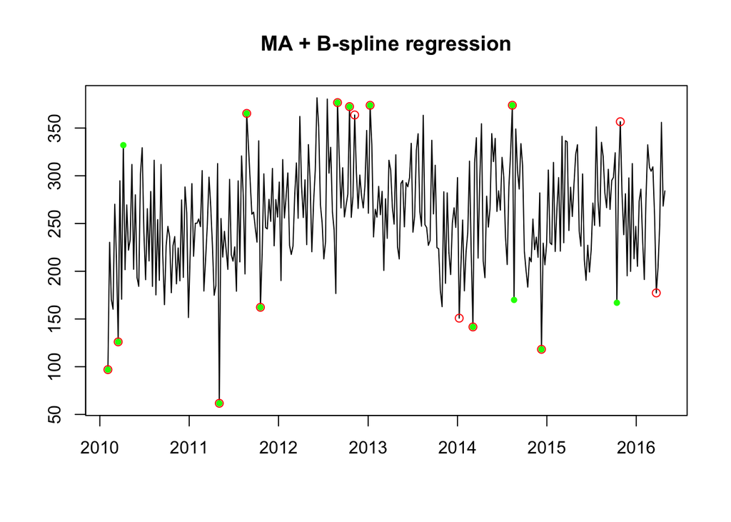

```r
## anoms detected by bs bspline
plot(temp$date, temp$new.sales, type = "l", xlab = "", ylab = "", main = "MA + B-spline regression")
points(anom_o$date, anom_o$new.sales, col = "red")
points(anom_bs$date, anom_bs$new.sales, col = "green", pch = 20)
```

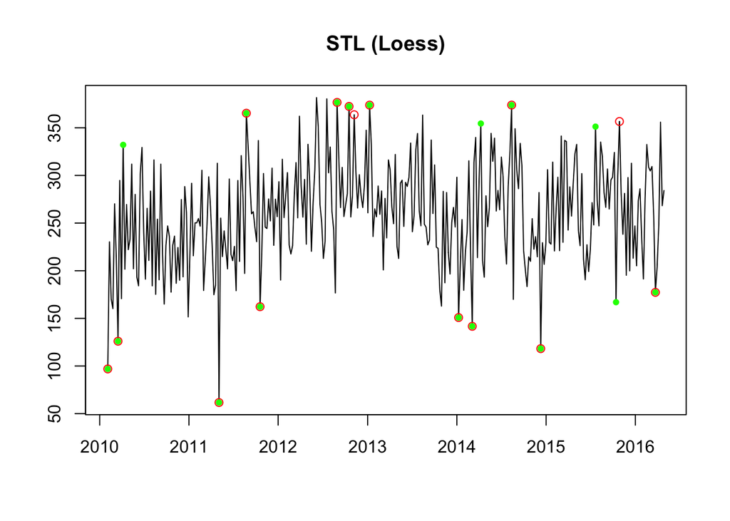

```r
## anoms detected by stl(loess)
plot(temp$date, temp$new.sales, type = "l", xlab = "", ylab = "", main = "STL (Loess)")
points(anom_o$date, anom_o$new.sales, col = "red")
points(anom_stl$date, anom_stl$new.sales, col = "green", pch = 20)
```